# Olympic Archery

## South Korea

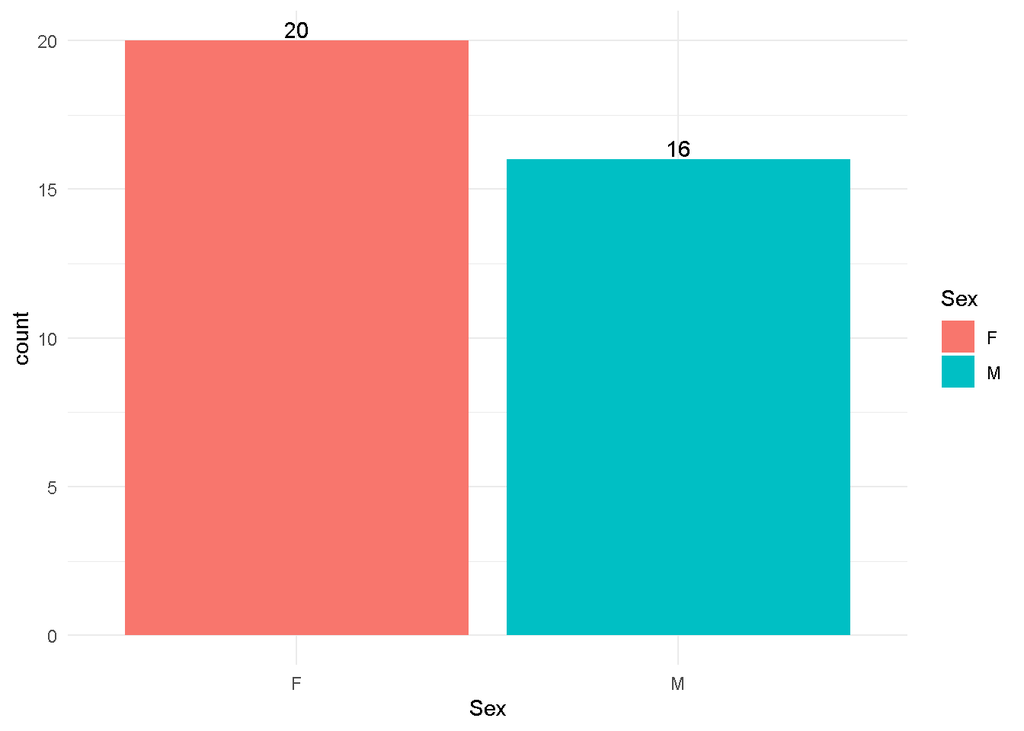

```r
SK_sex<-Archery%>%
  filter(Team=="South Korea",
         Medal!=is.na(NA)) %>%
  group_by(Name, Sex) %>%
   summarise(count=n())

ggplot(SK_sex,aes(x=Sex,fill=Sex))+
  geom_bar()+
   theme_minimal()+
  geom_text(aes(label = ..count..),stat="count",vjust = -0.2)
```

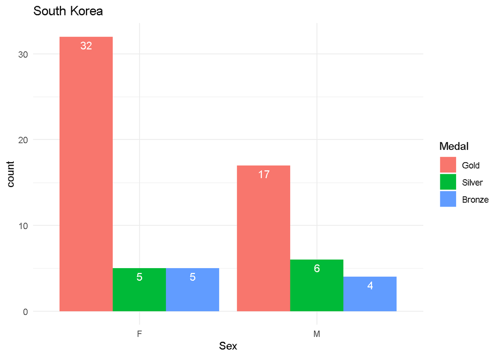

```r
s_korea<-Archery %>%
  filter(Team=="South Korea",
         Medal!=is.na(NA))
ggplot(s_korea,aes(x=Sex,fill=Medal))+
  geom_bar(position="dodge")+
  labs(title="South Korea")+
  theme_minimal()+
  geom_text(aes(label = ..count..), stat = "count", vjust = 1.5, colour = "white", position=position_dodge(.9))
```

## Belgium

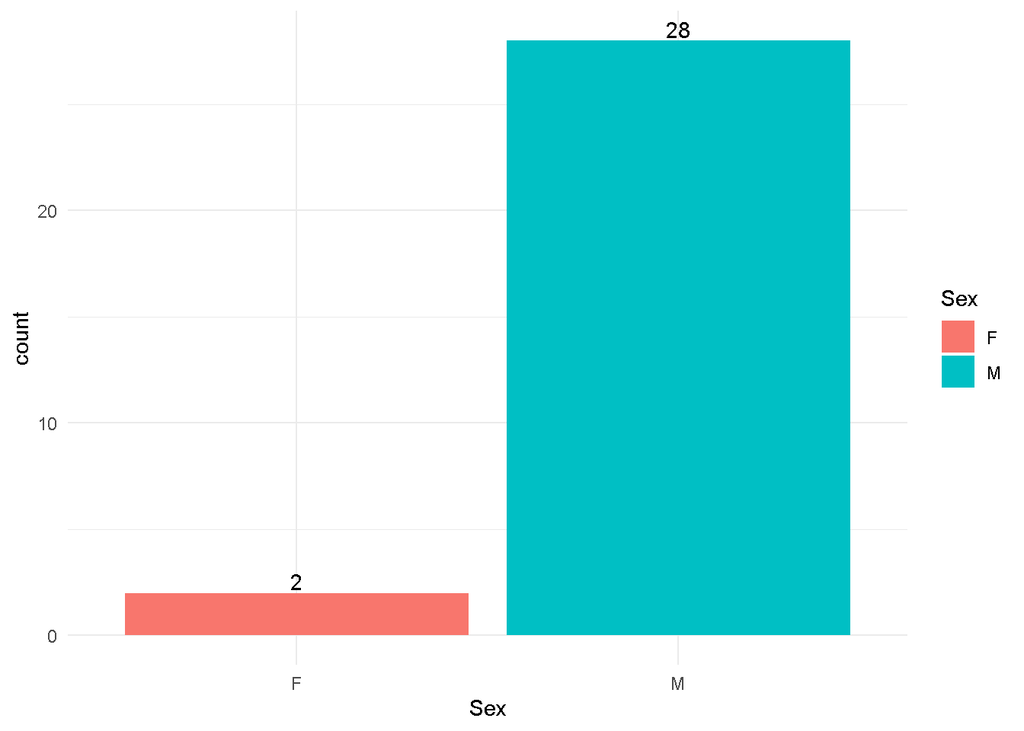

```r
B_sex<-Archery%>%
  filter(Team=="Belgium") %>%
  group_by(Name, Sex) %>%
  summarise(count=n())

ggplot(B_sex,aes(x=Sex,fill=Sex))+
  geom_bar()+
  theme_minimal()+
  geom_text(aes(label = ..count..),stat="count",vjust = -0.2)
```

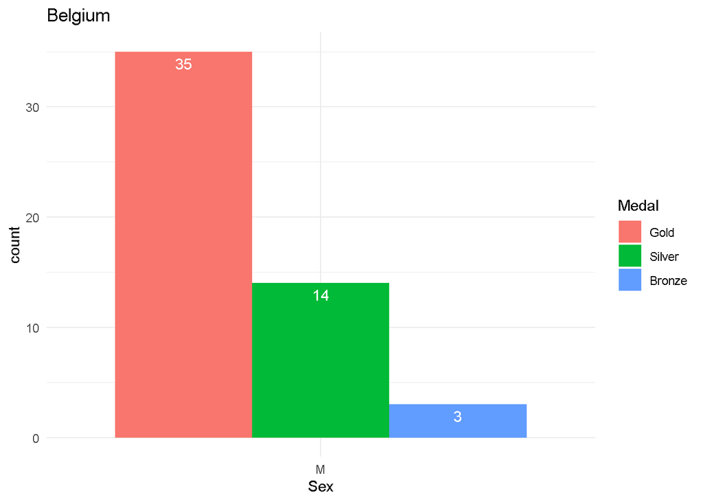

```r
belgium<-Archery %>%
  filter(Team=="Belgium",
         Medal!=is.na(NA))
ggplot(belgium,aes(x=Sex,fill=Medal))+
  geom_bar(position="dodge")+
  theme_minimal()+
  labs(title="Belgium")+
  geom_text(aes(label = ..count..), stat = "count", vjust = 1.5, colour = "white", position=position_dodge(.9))
```

For Belgium, the first bar plot shows taht 28 unique male participated in the Olympics and only 2 unique female participants. Only males have won medals: 35 gold medals, 14 silver medals , and 3 bronze medals. Here we can see if Belgium can find or train more females into archery, it could be possible they can earn more medals to beat South Korea.